# Expression data from renal cancer xenograft tumor treated with sunitinib or vehicle

Antón Vega

GEO accession number: GSE66346

## Description of the study

#### First, let’s have a little description of our dataset:

The main objective of the experiment from which the data was obtained was to compare the gene expression profile of a xenofraft tumor with one that was vehicle-treated. To do so, a microarray analysis was performed, and 40 mg/day of sunitinib was orally administrated.

#### Also, let’s have a description of the data:

To describe the data let’s look at the elements of the experimental design (looking at the response variable, the experimental factors, the sample size, etc):

- The response variable for the study is the gene expression, done by array.
- In our study we have 3 groups, 2 of which developed resistance to the sunitinib.
- The factors and levels are the comparison between vehicle and sunitinib
- The experiment had 9 samples.
- The number of experimental units per each combination is a bit weird in this experiment, but we have 2 different possible vehicles and 2 different sunitinib (resistance and sensitive) and 2 different of each type, although not every single one was given to each group.
- The type of experimental design is a Randomized design (CRD)

This samples have each: a accession number, the title of the sample, a source name, the type of tissue it affected, the kind of treatment they had and the xenograf mode.

##### We’ll breifly talk about the comparisons between groups:

> Now let’s start working with our data

First, we’ll download and correctly label our samples. We will alse normalize the data with a log2:

```r
library(Biobase)
library(GEOquery)
library(limma)

gset <- getGEO("GSE66346", GSEMatrix =TRUE, getGPL=FALSE)
if (length(gset) > 1) idx <- grep("GSE66346", attr(gset, "names")) else idx <- 1
gset <- gset[[idx]]
fvarLabels(gset) <- make.names(fvarLabels(gset))

# Assuming that in this experiment the vehicle was the control group
# and the sunitinib-sensitive the G0:

sml <- c("X","X","G0","G1","G1","X","G0","X","G1");

# We eliminate the control samples

sel <- which(sml != "X")
sml <- sml[sel]
gset <- gset[ ,sel]

ex <- exprs(gset)
qx <- as.numeric(quantile(ex, c(0., 0.25, 0.5, 0.75, 0.99, 1.0), na.rm=T))
LogC <- (qx[5] > 100) ||
  (qx[6]-qx[1] > 50 && qx[2] > 0) ||
  (qx[2] > 0 && qx[2] < 1 && qx[4] > 1 && qx[4] < 2)

if (LogC) { ex[which(ex <= 0)] <- NaN
            exprs(gset) <- log2(ex) }
```

> Then, we’ll do a boxlot of the data in our samples to understand what are we working with:

```r
dev.new(width=4+dim(gset)[[2]]/5, height=6)
par(mar=c(2+round(max(nchar(sampleNames(gset)))/2),4,2,1))
title <- paste ("GSE66346",'/',annotation(gset)," selected samples", sep ='')
boxplot(exprs(gset), boxwex=0.7, notch=T, main=title, outline=FALSE, las=2)
```

Since the boxplot does not show up on the r markdown file we will include a picture of the output of the code above:

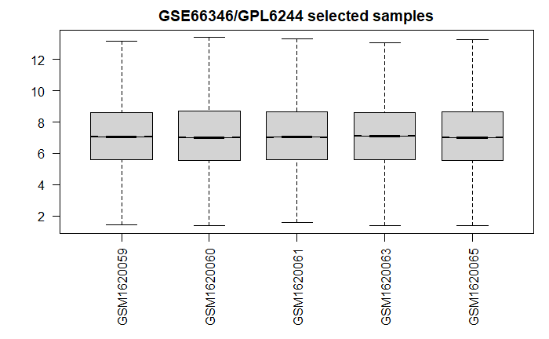

## Design matrices

Now we’ll design the experimental matrix and the contrast matrix.

### Experimental matrix

```r
Linear_model <- matrix(0, nrow = 9, ncol = 3)
colnames(Linear_model)<- c("GROUP", "VEHICLE", "SUNITINIB")
rownames(Linear_model)<- c("Sample 1","Sample 2","Sample 3","Sample 4","Sample 5","Sample 6","Sample 7","Sample 8","Sample 9")
Linear_model[, "GROUP"] <- c("KURC1", "KURC1","KURC2","KURC3","KURC1","KURC1","KURC3","KURC1","KURC2")
Linear_model[1:4, "VEHICLE"] <- c(1,1,1,1)
Linear_model[5:9, "SUNITINIB"] <- c(1,1,1,1,1)

knitr::kable(Linear_model)
```

|  | GROUP | VEHICLE | SUNITINIB |
| --- | --- | --- | --- |
| Sample 1 | KURC1 | 1 | 0 |
| Sample 2 | KURC1 | 1 | 0 |
| Sample 3 | KURC2 | 1 | 0 |
| Sample 4 | KURC3 | 1 | 0 |
| Sample 5 | KURC1 | 0 | 1 |
| Sample 6 | KURC1 | 0 | 1 |
| Sample 7 | KURC3 | 0 | 1 |
| Sample 8 | KURC1 | 0 | 1 |
| Sample 9 | KURC2 | 0 | 1 |

### Contrast matrix

```r
fl <- as.factor(sml)
gset$description <- fl
design <- model.matrix(~ description + 0, gset)
colnames(design) <- levels(fl)
fit <- lmFit(gset, design)
cont.matrix <- makeContrasts(G1-G0,levels=design)

knitr::kable(cont.matrix)
```

|  | G1 - G0 |
| --- | --- |
| G0 | -1 |
| G1 | 1 |

> Volcano plot:

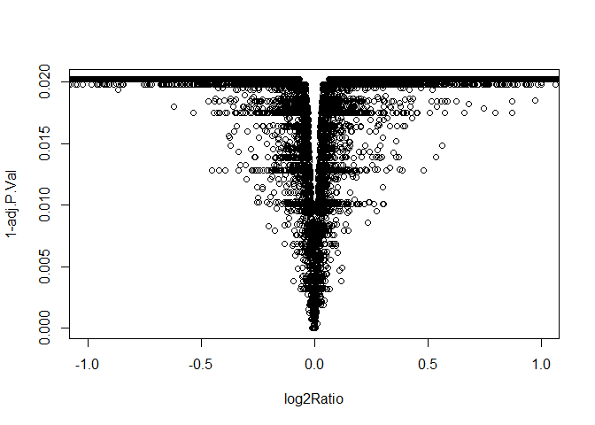

```r
fit2 <- contrasts.fit(fit, cont.matrix)
fit2 <- eBayes(fit2, 0.01)
tT <- topTable(fit2, adjust="fdr", sort.by="B", number=nrow(fit2))
plot(tT$logFC, 1-tT$adj.P.Val, xlim=c(-1, 1),
     xlab="log2Ratio", ylab="1-adj.P.Val")
```